# **Capstone project: Providing data-driven suggestions for HR**

## Description and deliverables

This capstone project is an opportunity for you to analyze a dataset and build predictive models that can provide insights to the Human Resources (HR) department of a large consulting firm.

Upon completion, you will have two artifacts that you would be able to present to future employers. One is a brief one-page summary of this project that you would present to external stakeholders as the data professional in Salifort Motors. The other is a complete code notebook provided here. Please consider your prior course work and select one way to achieve this given project question. Either use a regression model or machine learning model to predict whether or not an employee will leave the company. The exemplar following this actiivty shows both approaches, but you only need to do one.

In your deliverables, you will include the model evaluation (and interpretation if applicable), a data visualization(s) of your choice that is directly related to the question you ask, ethical considerations, and the resources you used to troubleshoot and find answers or solutions.

# **PACE stages**

## **Pace: Plan**

Consider the questions in your PACE Strategy Document to reflect on the Plan stage.

In this stage, consider the following:

### Understand the business scenario and problem

The HR department at Salifort Motors wants to take some initiatives to improve employee satisfaction levels at the company. They collected data from employees, but now they don’t know what to do with it. They refer to you as a data analytics professional and ask you to provide data-driven suggestions based on your understanding of the data. They have the following question: what’s likely to make the employee leave the company?

Your goals in this project are to analyze the data collected by the HR department and to build a model that predicts whether or not an employee will leave the company.

If you can predict employees likely to quit, it might be possible to identify factors that contribute to their leaving. Because it is time-consuming and expensive to find, interview, and hire new employees, increasing employee retention will be beneficial to the company.

### Familiarize yourself with the HR dataset

The dataset that you'll be using in this lab contains 15,000 rows and 10 columns for the variables listed below.

**Note:** you don't need to download any data to complete this lab. For more information about the data, refer to its source on [Kaggle](https://www.kaggle.com/datasets/mfaisalqureshi/hr-analytics-and-job-prediction?select=HR_comma_sep.csv).

| Variable | Description |  |
| --- | --- | --- |
| satisfaction_level | Employee-reported job satisfaction level [0–1] |  |
| last_evaluation | Score of employee's last performance review [0–1] |  |
| number_project | Number of projects employee contributes to |  |
| average_monthly_hours | Average number of hours employee worked per month |  |
| time_spend_company | How long the employee has been with the company (years) |  |
| Work_accident | Whether or not the employee experienced an accident while at work |  |
| left | Whether or not the employee left the company |  |
| promotion_last_5years | Whether or not the employee was promoted in the last 5 years |  |
| Department | The employee's department |  |
| salary | The employee's salary (U.S. dollars) |  |

💭

### Reflect on these questions as you complete the plan stage.

- Who are your stakeholders for this project?
- What are you trying to solve or accomplish?
- What are your initial observations when you explore the data?
- What resources do you find yourself using as you complete this stage? (Make sure to include the links.)
- Do you have any ethical considerations in this stage?

```
1. HR Department personnel are  the stakeholders for this project
2. By following all the steps in PACE strategies as studied throughout the course.
3. We have nearly 14999 rows of data that gives information about factors that are affecting the employee satisfaction
4. By integrating these ethical considerations into the planning stage of data analytics, you can help ensure that your
analysis is conducted ethically, responsibly, and in alignment with principles of fairness, transparency, and respect
for individuals' rights and well-being.
```

## Step 1. Imports

- Import packages
- Load dataset

### Import packages

```python
# Import necessary libraries

import numpy as np
import pandas as pd
import seaborn as sns
import matplotlib.pyplot as plt
%matplotlib inline
import sklearn.metrics as metrics
from scipy import stats
from scipy.stats import zscore
from sklearn.neighbors import KNeighborsClassifier
from sklearn.model_selection import train_test_split
from sklearn.preprocessing import MinMaxScaler
from sklearn.linear_model import LogisticRegression
from sklearn.metrics import accuracy_score, confusion_matrix
from sklearn.preprocessing import LabelEncoder
from sklearn.naive_bayes import GaussianNB
from sklearn.svm import SVC
from sklearn.metrics import classification_report
from sklearn import model_selection
from sklearn.tree import DecisionTreeClassifier
from sklearn.tree import export_graphviz
from IPython.display import Image
from sklearn.tree import plot_tree
from sklearn.ensemble import RandomForestClassifier
from sklearn.ensemble import BaggingClassifier
from sklearn.ensemble import AdaBoostClassifier
from sklearn.ensemble import GradientBoostingClassifier
import xgboost as xgb
from xgboost import XGBClassifier
from sklearn.model_selection import RandomizedSearchCV
from sklearn.model_selection import GridSearchCV
import warnings
warnings.filterwarnings("ignore")
```

### Load dataset

`Pandas` is used to read a dataset called **`HR_capstone_dataset.csv`.** As shown in this cell, the dataset has been automatically loaded in for you. You do not need to download the .csv file, or provide more code, in order to access the dataset and proceed with this lab. Please continue with this activity by completing the following instructions.

```python
# RUN THIS CELL TO IMPORT YOUR DATA.

# Load dataset into a dataframe
### YOUR CODE HERE ###
df0 = pd.read_csv("HR_capstone_dataset.csv")


# Display first few rows of the dataframe
### YOUR CODE HERE ###
df0.head().style.set_properties(**{'border': '1.3px solid black','color': 'blue'}).hide_index()
```

| satisfaction_level | last_evaluation | number_project | average_montly_hours | time_spend_company | Work_accident | left | promotion_last_5years | Department | salary |
| --- | --- | --- | --- | --- | --- | --- | --- | --- | --- |
| 0.380000 | 0.530000 | 2 | 157 | 3 | 0 | 1 | 0 | sales | low |
| 0.800000 | 0.860000 | 5 | 262 | 6 | 0 | 1 | 0 | sales | medium |
| 0.110000 | 0.880000 | 7 | 272 | 4 | 0 | 1 | 0 | sales | medium |
| 0.720000 | 0.870000 | 5 | 223 | 5 | 0 | 1 | 0 | sales | low |
| 0.370000 | 0.520000 | 2 | 159 | 3 | 0 | 1 | 0 | sales | low |

## Step 2. Data Exploration (Initial EDA and data cleaning)

- Understand your variables
- Clean your dataset (missing data, redundant data, outliers)

### Gather basic information about the data

```python
# Gather basic information about the data
df0.info()
```

```
<class 'pandas.core.frame.DataFrame'>
RangeIndex: 14999 entries, 0 to 14998
Data columns (total 10 columns):
 #   Column                 Non-Null Count  Dtype
---  ------                 --------------  -----
 0   satisfaction_level     14999 non-null  float64
 1   last_evaluation        14999 non-null  float64
 2   number_project         14999 non-null  int64
 3   average_montly_hours   14999 non-null  int64
 4   time_spend_company     14999 non-null  int64
 5   Work_accident          14999 non-null  int64
 6   left                   14999 non-null  int64
 7   promotion_last_5years  14999 non-null  int64
 8   Department             14999 non-null  object
 9   salary                 14999 non-null  object
dtypes: float64(2), int64(6), object(2)
memory usage: 1.1+ MB
```

### Gather descriptive statistics about the data

```python
# Gather descriptive statistics about the data
df0.describe().style.set_properties(**{'border': '1.3px solid black','color': 'blue'}).hide_index()
```

| satisfaction_level | last_evaluation | number_project | average_montly_hours | time_spend_company | Work_accident | left | promotion_last_5years |
| --- | --- | --- | --- | --- | --- | --- | --- |
| 14999.000000 | 14999.000000 | 14999.000000 | 14999.000000 | 14999.000000 | 14999.000000 | 14999.000000 | 14999.000000 |
| 0.612834 | 0.716102 | 3.803054 | 201.050337 | 3.498233 | 0.144610 | 0.238083 | 0.021268 |
| 0.248631 | 0.171169 | 1.232592 | 49.943099 | 1.460136 | 0.351719 | 0.425924 | 0.144281 |
| 0.090000 | 0.360000 | 2.000000 | 96.000000 | 2.000000 | 0.000000 | 0.000000 | 0.000000 |
| 0.440000 | 0.560000 | 3.000000 | 156.000000 | 3.000000 | 0.000000 | 0.000000 | 0.000000 |
| 0.640000 | 0.720000 | 4.000000 | 200.000000 | 3.000000 | 0.000000 | 0.000000 | 0.000000 |
| 0.820000 | 0.870000 | 5.000000 | 245.000000 | 4.000000 | 0.000000 | 0.000000 | 0.000000 |
| 1.000000 | 1.000000 | 7.000000 | 310.000000 | 10.000000 | 1.000000 | 1.000000 | 1.000000 |

### Rename columns

As a data cleaning step, rename the columns as needed. Standardize the column names so that they are all in `snake_case`, correct any column names that are misspelled, and make column names more concise as needed.

```python
# Display all column names
df0.columns
```

```
Index(['satisfaction_level', 'last_evaluation', 'number_project',
       'average_montly_hours', 'time_spend_company', 'Work_accident', 'left',
       'promotion_last_5years', 'Department', 'salary'],
      dtype='object')
```

```python
# Rename columns as needed
#Correcting spelling mistakes, changing to lower case, and simplifying the column names as needed for better readability
df0 = df0.rename(columns={'Work_accident': 'work_accident',
                          'average_montly_hours': 'average_monthly_hours',
                          'time_spend_company': 'tenure',
                          'Department': 'department'})

# Display all column names after the update
### YOUR CODE HERE ###
df0.columns
```

```
Index(['satisfaction_level', 'last_evaluation', 'number_project',
       'average_monthly_hours', 'tenure', 'work_accident', 'left',
       'promotion_last_5years', 'department', 'salary'],
      dtype='object')
```

### Check missing values

Check for any missing values in the data.

```python
# Check for missing values

if(df0.isna().sum().sum() == 0):
    print('\nThere are no missing values in the data set')
else:
    print('\nThere are',df0.isna().sum().sum(),'missing values in the data set')
    print('\n')
    print(df0.isna().sum())
```

```
There are no missing values in the data set
```

### Check duplicates

Check for any duplicate entries in the data.

```python
# Check for duplicates

if(df0.duplicated().sum() == 0):
    print('\nThere are no duplicate values in the data set')
else:
    print('\nThere are',df0.duplicated().sum(),'duplicate values in the data set')
```

```
There are 3008 duplicate values in the data set
```

```python
# Inspect some rows containing duplicates as needed
df0[df0.duplicated()].sample(10).style.set_properties(**{'border': '1.3px solid black','color': 'blue'}).hide_index()
```

| satisfaction_level | last_evaluation | number_project | average_monthly_hours | tenure | work_accident | left | promotion_last_5years | department | salary |
| --- | --- | --- | --- | --- | --- | --- | --- | --- | --- |
| 0.370000 | 0.530000 | 2 | 131 | 3 | 0 | 1 | 0 | sales | low |
| 0.950000 | 0.810000 | 4 | 258 | 7 | 0 | 0 | 1 | sales | medium |
| 0.110000 | 0.870000 | 6 | 257 | 4 | 0 | 1 | 0 | support | medium |
| 0.750000 | 0.920000 | 3 | 211 | 3 | 0 | 0 | 0 | sales | medium |
| 0.410000 | 0.540000 | 2 | 152 | 3 | 0 | 1 | 0 | technical | low |
| 0.900000 | 0.960000 | 5 | 243 | 5 | 0 | 1 | 0 | technical | medium |
| 0.430000 | 0.480000 | 2 | 153 | 3 | 0 | 1 | 0 | accounting | low |
| 0.860000 | 0.680000 | 5 | 263 | 2 | 0 | 1 | 0 | technical | medium |
| 0.090000 | 0.800000 | 6 | 301 | 5 | 0 | 1 | 0 | IT | medium |
| 0.790000 | 0.650000 | 3 | 235 | 10 | 0 | 0 | 0 | technical | low |

```python
# Drop duplicates and save resulting dataframe in a new variable as needed

print('\nDropping the duplicate values from the data set...\n')
df1 = df0.drop_duplicates(keep='first')

if(df1.duplicated().sum() == 0):
    print('\nThere are no duplicate values in the data set...\n\n')
else:
    print('\nThere are',df1.duplicated().sum(),'duplicate values in the data set')


# Display first few rows of new dataframe as needed
df1.head().style.set_properties(**{'border': '1.3px solid black','color': 'blue'}).hide_index()
```

```
Dropping the duplicate values from the data set...


There are no duplicate values in the data set...
```

| satisfaction_level | last_evaluation | number_project | average_monthly_hours | tenure | work_accident | left | promotion_last_5years | department | salary |
| --- | --- | --- | --- | --- | --- | --- | --- | --- | --- |
| 0.380000 | 0.530000 | 2 | 157 | 3 | 0 | 1 | 0 | sales | low |
| 0.800000 | 0.860000 | 5 | 262 | 6 | 0 | 1 | 0 | sales | medium |
| 0.110000 | 0.880000 | 7 | 272 | 4 | 0 | 1 | 0 | sales | medium |
| 0.720000 | 0.870000 | 5 | 223 | 5 | 0 | 1 | 0 | sales | low |
| 0.370000 | 0.520000 | 2 | 159 | 3 | 0 | 1 | 0 | sales | low |

### Check outliers

Check for outliers in the data.

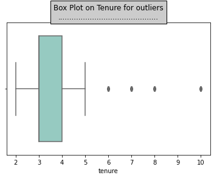

```python
# Create a boxplot to visualize distribution of `tenure` and detect any outliers
figsize=(35,15)
sns.boxplot(x=df1['tenure'], palette="Set3", dodge = False)
plt.title("Box Plot on Tenure for outliers\n" + "............................................", bbox={'facecolor':'0.8', 'pad':5})
plt.show()
```

```python
# Determine the number of rows containing outliers
### YOUR CODE HERE ###

# Compute the 25th percentile value in `tenure`
per25 = df1['tenure'].quantile(0.25)

# Compute the 75th percentile value in `tenure`
per75 = df1['tenure'].quantile(0.75)

# Compute the interquartile range in `tenure`
iqr = per75 - per25

# Define the upper limit and lower limit for non-outlier values in `tenure`
upper_limit = per75 + 1.5 * iqr
lower_limit = per25 - 1.5 * iqr
print("Lower limit:", lower_limit)
print("Upper limit:", upper_limit)

# Identify subset of data containing outliers in `tenure`
outlier_info = df1[(df1['tenure'] > upper_limit) | (df1['tenure'] < lower_limit)]

# Count how many rows in the data contain outliers in `tenure`
print("Total count of outlies in the column tenure:", len(outlier_info))
```

```
Lower limit: 1.5
Upper limit: 5.5
Total count of outlies in the column tenure: 824
```

Certain types of models are more sensitive to outliers than others. When you get to the stage of building your model, consider whether to remove outliers, based on the type of model you decide to use.

# pAce: Analyze Stage

- Perform EDA (analyze relationships between variables)

💭

### Reflect on these questions as you complete the analyze stage.

- What did you observe about the relationships between variables?
- What do you observe about the distributions in the data?
- What transformations did you make with your data? Why did you chose to make those decisions?
- What are some purposes of EDA before constructing a predictive model?
- What resources do you find yourself using as you complete this stage? (Make sure to include the links.)
- Do you have any ethical considerations in this stage?

[output not shown]

## Step 2. Data Exploration (Continue EDA)

Begin by understanding how many employees left and what percentage of all employees this figure represents.

```python
# Get numbers of people who left vs. stayed
### YOUR CODE HERE ###
print(df1['left'].value_counts())
print()

# Get percentages of people who left vs. stayed
### YOUR CODE HERE ###
print(df1['left'].value_counts(normalize=True))
```

```
0    10000
1     1991
Name: left, dtype: int64

0    0.833959
1    0.166041
Name: left, dtype: float64
```

### Data visualizations

Now, examine variables that you're interested in, and create plots to visualize relationships between variables in the data.

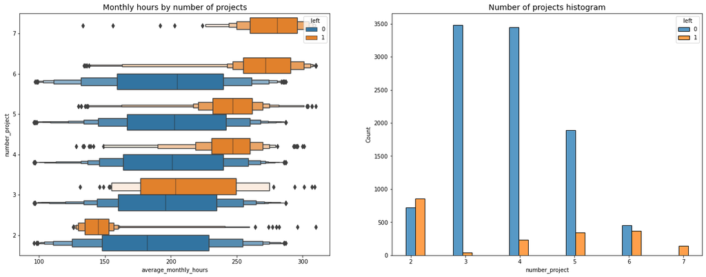

```python
# Create a plot as needed
### YOUR CODE HERE ###

# Set figure and axes
fig, ax = plt.subplots(1, 2, figsize = (22,8))

# Create boxplot showing `average_monthly_hours` distributions for `number_project`, comparing employees who stayed versus those who left
sns.boxenplot(data=df1, x='average_monthly_hours', y='number_project', hue='left', orient="h", ax=ax[0])
ax[0].invert_yaxis()
ax[0].set_title('Monthly hours by number of projects', fontsize='14')

# Create histogram showing distribution of `number_project`, comparing employees who stayed versus those who left
tenure_stay = df1[df1['left']==0]['number_project']
tenure_left = df1[df1['left']==1]['number_project']
sns.histplot(data=df1, x='number_project', hue='left', multiple='dodge', shrink=2, ax=ax[1])
ax[1].set_title('Number of projects histogram', fontsize='14')

# Display the plots
plt.show()
```

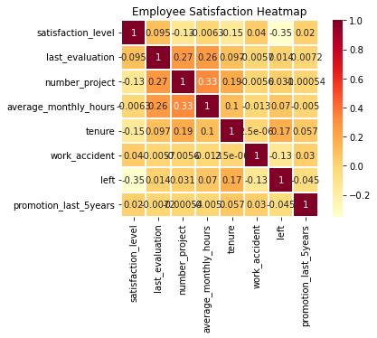

```python
# Create a plot as needed

ax = sns.heatmap(df1.corr(), annot = True, linewidths = 1, square = True, cmap="YlOrRd")

plt.title("Employee Satisfaction Heatmap")

plt. show()
```

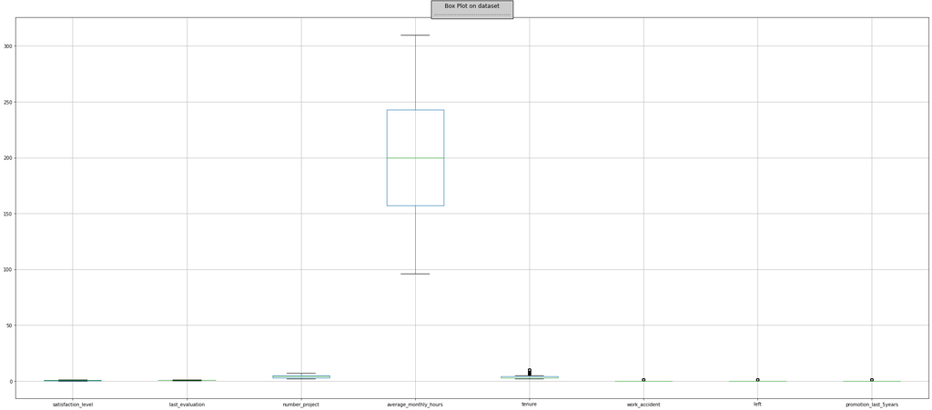

```python
# Create a plot as needed

df1.boxplot(figsize=(35,15))
plt.title("Box Plot on dataset\n" + "............................................", bbox={'facecolor':'0.8', 'pad':5})
plt.show()
```

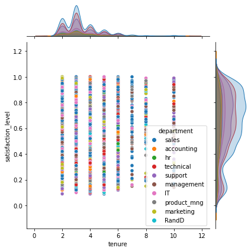

```python
# Create a plot as needed

sns.jointplot(x="tenure",y="satisfaction_level",data=df1,hue="department",marker="o")
plt.show()
```

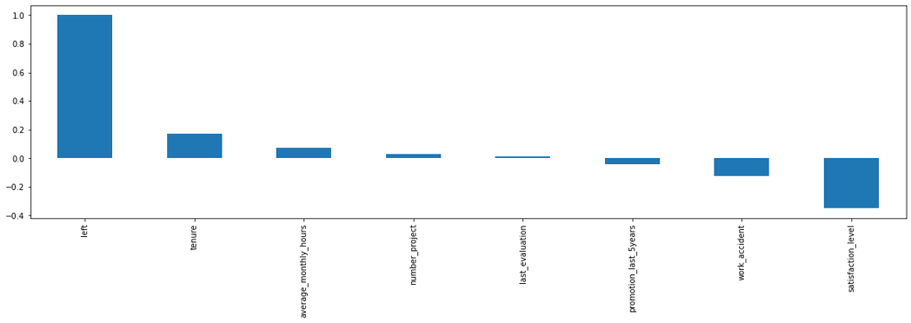

```python
def CORR_PLOT(DF_FINAL):
    plt.figure(figsize = (16,10))
    DF_FINAL.corr()['left'].sort_values(ascending = False).plot(kind = 'bar', figsize = (20,5))
    plt.show()

CORR_PLOT(df1)
```

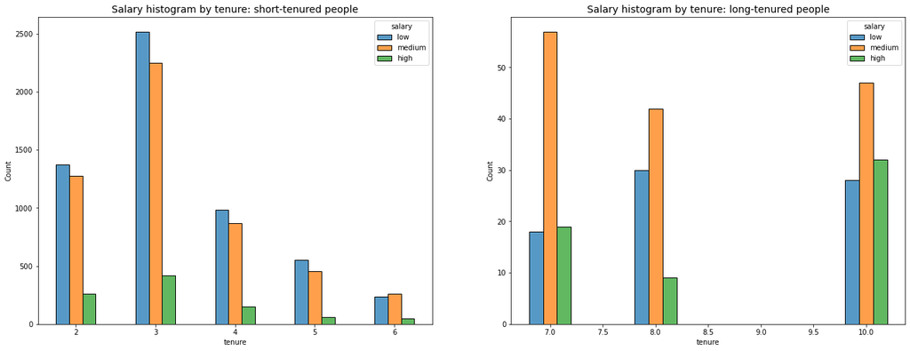

```python
# Create a plot as needed
### YOUR CODE HERE ###

# Set figure and axes
fig, ax = plt.subplots(1, 2, figsize = (22,8))

# Define short-tenured employees
tenure_short = df1[df1['tenure'] < 7]

# Define long-tenured employees
tenure_long = df1[df1['tenure'] > 6]

# Plot short-tenured histogram
sns.histplot(data=tenure_short, x='tenure', hue='salary', discrete=1,
             hue_order=['low', 'medium', 'high'], multiple='dodge', shrink=.5, ax=ax[0])
ax[0].set_title('Salary histogram by tenure: short-tenured people', fontsize='14')

# Plot long-tenured histogram
sns.histplot(data=tenure_long, x='tenure', hue='salary', discrete=1,
             hue_order=['low', 'medium', 'high'], multiple='dodge', shrink=.4, ax=ax[1])
ax[1].set_title('Salary histogram by tenure: long-tenured people', fontsize='14');
```

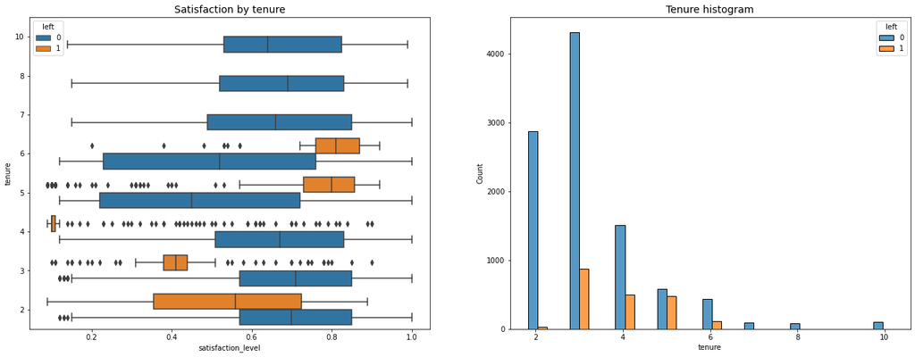

```python
# Create a plot as needed
### YOUR CODE HERE ###

# Set figure and axes
fig, ax = plt.subplots(1, 2, figsize = (22,8))

# Create boxplot showing distributions of `satisfaction_level` by tenure, comparing employees who stayed versus those who left
sns.boxplot(data=df1, x='satisfaction_level', y='tenure', hue='left', orient="h", ax=ax[0])
ax[0].invert_yaxis()
ax[0].set_title('Satisfaction by tenure', fontsize='14')

# Create histogram showing distribution of `tenure`, comparing employees who stayed versus those who left
tenure_stay = df1[df1['left']==0]['tenure']
tenure_left = df1[df1['left']==1]['tenure']
sns.histplot(data=df1, x='tenure', hue='left', multiple='dodge', shrink=5, ax=ax[1])
ax[1].set_title('Tenure histogram', fontsize='14')

plt.show();
```

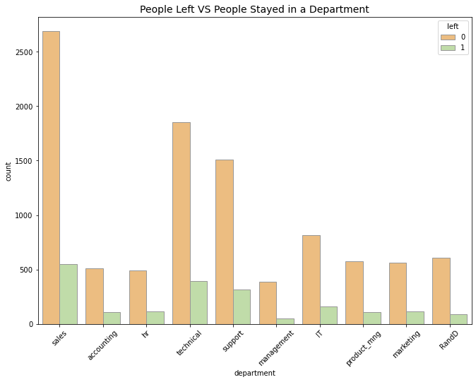

```python
plt.figure(figsize=(11,8))
sns.countplot(data = df1, x = "department",hue = "left", edgecolor = ".6",palette = "Spectral")
plt.xticks(rotation='45')
plt.title('People Left VS People Stayed in a Department', fontsize=14);
plt.show()
```

### Insights

It might be natural that people who work on more projects would also work longer hours. This appears to be the case here, with the mean hours of each group (stayed and left) increasing with number of projects worked. However, a few things stand out from this plot.

1. There are two groups of employees who left the company: (A) those who worked considerably less than their peers with the same number of projects, and (B) those who worked much more. Of those in group A, it's possible that they were fired. It's also possible that this group includes employees who had already given their notice and were assigned fewer hours because they were already on their way out the door. For those in group B, it's reasonable to infer that they probably quit. The folks in group B likely contributed a lot to the projects they worked in; they might have been the largest contributors to their projects.
2. Everyone with seven projects left the company, and the interquartile ranges of this group and those who left with six projects was ~255–295 hours/month—much more than any other group.
3. The optimal number of projects for employees to work on seems to be 3–4. The ratio of left/stayed is very small for these cohorts.
4. If you assume a work week of 40 hours and two weeks of vacation per year, then the average number of working hours per month of employees working Monday–Friday `= 50 weeks * 40 hours per week / 12 months = 166.67 hours per month`. This means that, aside from the employees who worked on two projects, every group—even those who didn't leave the company—worked considerably more hours than this. It seems that employees here are overworked.

# paCe: Construct Stage

- Determine which models are most appropriate
- Construct the model
- Confirm model assumptions
- Evaluate model results to determine how well your model fits the data

🔎

## Recall model assumptions

**Logistic Regression model assumptions**

- Outcome variable is categorical
- Observations are independent of each other
- No severe multicollinearity among X variables
- No extreme outliers
- Linear relationship between each X variable and the logit of the outcome variable
- Sufficiently large sample size

💭

### Reflect on these questions as you complete the constructing stage.

- Do you notice anything odd?
- Which independent variables did you choose for the model and why?
- Are each of the assumptions met?
- How well does your model fit the data?
- Can you improve it? Is there anything you would change about the model?
- What resources do you find yourself using as you complete this stage? (Make sure to include the links.)
- Do you have any ethical considerations in this stage?

```
- I have selected all the independent variables available as I felt that satisfaction of the employee is dependent on all the parameters given in the data. Even though it overfits the data and most probably inclines to a single class, I will still proceed with given data as is and wants to know how well it fares with the data provided. This will help me to give exact conclusions based on the data provided by the stake holders as is. This will help them in future to provide the data that has less bias and also include more parameters that might affect the analysis. I have choose almost all the models from Regression, Supervised Learning, Unsupervised Learning, Ensemble Techniques to know which model works well on the data and this helps me to stick with one best working model, incase I get more data from the same stake holders and eases my work. I have done as many trainings on the data and selected the XGBoost as the final best model that fits all my data and having good prediction accuracy. Along with the predictions, I have included the confusion matrix and heat maps that gives how well they are predicting the data.
```

## Step 3. Model Building, Step 4. Results and Evaluation

- Fit a model that predicts the outcome variable using two or more independent variables
- Check model assumptions
- Evaluate the model

### Identify the type of prediction task.

```
- The model has to predict the likelihood of employee leaving the company to staying based on the independent variables
```

### Identify the types of models most appropriate for this task.

```
- I have selected all models of my knowledge to make use of and finally predict the best working model that fits data
```